# PROJECT : Wrangle And Analyze Data - ['Twitter-Datasets']

- Introduction
- Data Wrangling
- Exploratory Data Analysis
- Conclusions

# Introduction

### Datasets Description

> **Datasets**:  
> 1- twitter-archive-enhanced  
> 2- tweet-json  
> 3- image-predictions  
> **Source**: Twitter udacity's guide

### informations about the used datasets

- there are 3 datasets that got extracted from twitter
- the id in each dataset is related to the other datasets
- the second dataset has json format

# Questions for Analysis

(1) What is the distribution of tweet ratings

(2) Which dog stage is most commonly mentioned

# Exploratory Data Analysis

### Descriptive Statistics

```python
#some info
```

|  | retweet_count | number of likes | img_num | p1_conf | p2_conf | p3_conf |
| --- | --- | --- | --- | --- | --- | --- |
| count | 2173.000000 | 2173.000000 | 2173.000000 | 2173.000000 | 2.173000e+03 | 2.173000e+03 |
| mean | 2755.002301 | 8745.364933 | 1.186378 | 0.594200 | 1.344407e-01 | 6.023924e-02 |
| std | 4644.881800 | 12055.554411 | 0.540069 | 0.260324 | 9.644224e-02 | 4.874321e-02 |
| min | 0.000000 | 52.000000 | 1.000000 | 0.044333 | 1.011300e-08 | 1.740170e-10 |
| 25% | 608.000000 | 1914.000000 | 1.000000 | 0.379624 | 5.952590e-02 | 1.844220e-02 |
| 50% | 1341.000000 | 4042.000000 | 1.000000 | 0.594548 | 1.295580e-01 | 5.826140e-02 |
| 75% | 3220.000000 | 11101.000000 | 1.000000 | 0.823919 | 1.870030e-01 | 8.702230e-02 |
| max | 79515.000000 | 132810.000000 | 4.000000 | 1.000000 | 4.880140e-01 | 2.734190e-01 |

--some observations--

## Values like 1.0113e-08 and 1.74e-10 suggest the model was very unsure

retweet_count and number of likes max values are very high  
This likely just indicates a few viral tweets. it may cause a problem if i work in a model, so i may need to remove outliers if i used these columns in analysis

### Data Visualization:

### Research Question 1 ('What is the distribution of tweet ratings?')

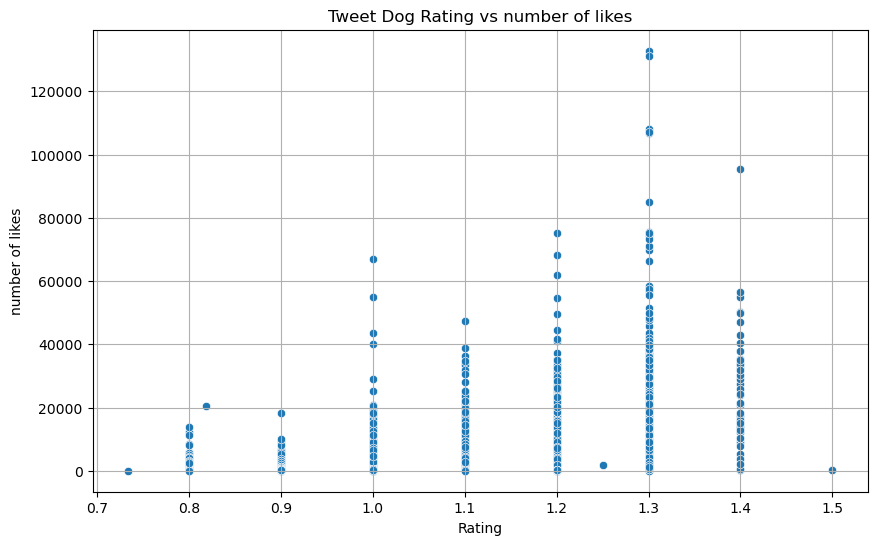

```python
#Dog rating vs Number of likes
```

### There's variation in number of likes per rating, which might indicate:

```
- Tweets with higher dog ratings (like 1.3) might get more attention.
```

### Research Question 2 ('Which dog stage is most commonly mentioned?')

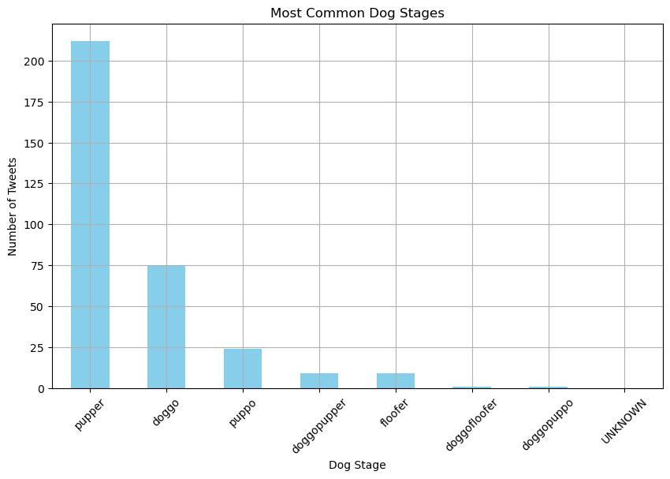

```python
#most popular dog stage is pupper
```

# Conclusions

Objective

- Extract insights (most common dog stages, rating distribution).
- Prepare a high-quality dataset suitable for further analysis or modeling.

### another useful researches that can be done in this dataset

**Breed vs Rating Analysis**  
**Breed Detection Model Performance**

### Limitations

- WeRateDogs uses inconsistent rating logic, which may not be suitable for objective analysis or predictive modeling.
- The predictions for dog breeds are not 100% accurate (for example: p2 and p3 models The model may predict objects like: banana, spatula)
- Majority of tweets came from iPhone users (http://twitter.com/download/iphone)